# Causes_alldata

2023-10-11

## Script to work on analyses for causes paper

##Taxonomic work is needed? # Morpho differentiation types: More CS sl than CS ss overall? # Need to find expectations and test against 50:50 mark

```
##
##  Pearson's Chi-squared test with Yates' continuity correction
##
## data:  cbind(expected, observed)
## X-squared = 31.693, df = 1, p-value = 1.806e-08
```

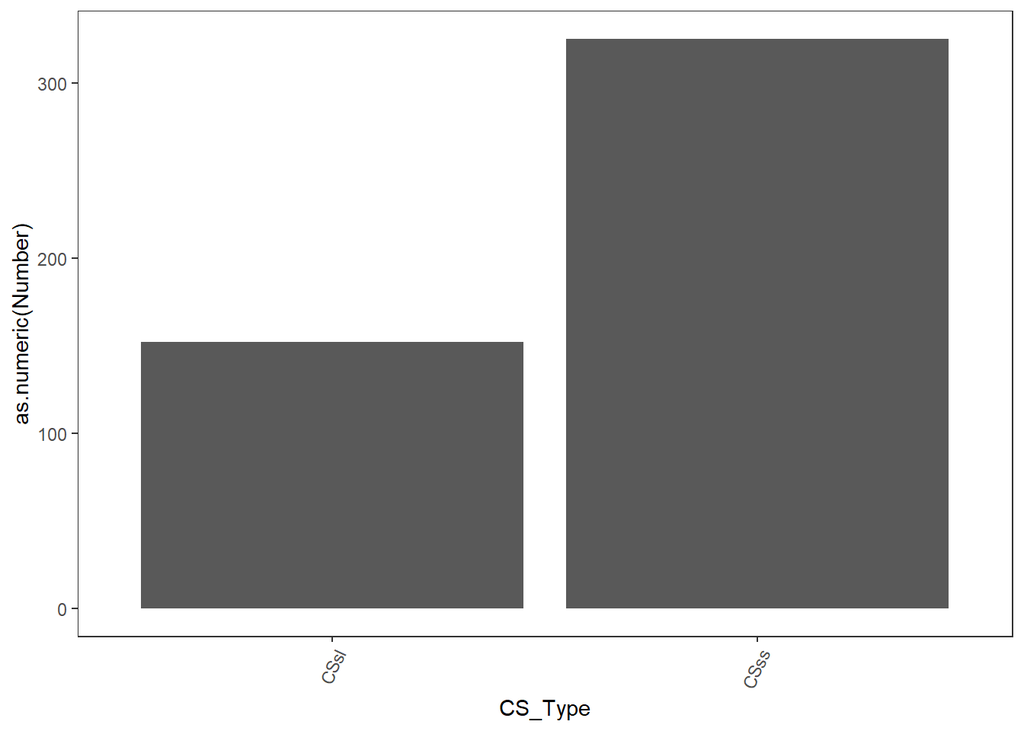

More CSss than the 50% benchmark (significant), so reject the idea that most CS are just due to taxonomic oversight.

# Available technology – More diagnostic differences in species described earlier?

```
##
##        FALSE TRUE
##   1750     4   16
##   1760     4    9
##   1770     1    8
##   1780     2    6
##   1790     1   12
##   1800     8    4
##   1810     7    8
##   1820    12   14
##   1830     8   16
##   1840     7   20
##   1850     5    9
##   1860    11   14
##   1870     6   13
##   1880     7    6
##   1890     3   10
##   1900     1   13
##   1910     2    4
##   1920     4    6
##   1930     5    6
##   1940     1    3
##   1950     1    6
##   1960     3    3
##   1970     3    7
##   1980     2    8
##   1990     5    7
##   2000     8   19
##   2010    12   20
```

```
##
##  Pearson's Chi-squared test
##
## data:  decademorpho$decade and decademorpho$CSss
## X-squared = 30.889, df = 26, p-value = 0.2324
```

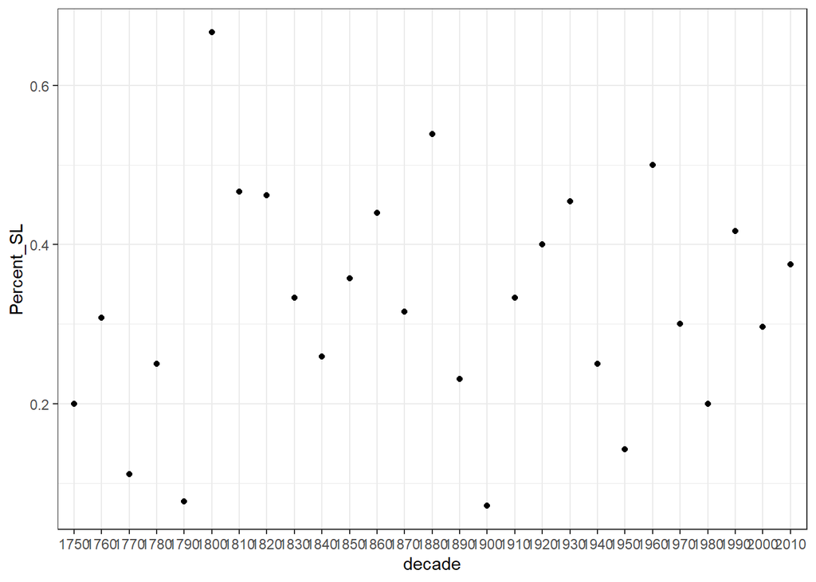

There is no trend in the percent of CSsl (diagnostic differences) through time; hypothesis not supported.

# Prevailing theories of nature and species origins - More CS in fragmented habitats in species described before Darwin?

```
##
##               1  10 100 1000  25   5
##   1756-1859   2 111  23   65  93  63
##   1860-1980   2  75  32   40  88  42
##   1981-2020   1  41  25    9  26  16
```

```
##
##  Pearson's Chi-squared test
##
## data:  breaks_HKK$decade_bin and breaks_HKK$HKK
## X-squared = 31.689, df = 10, p-value = 0.0004511
```

```
##                      1        10        100       1000        25         5
## pre_Darwin 0.005602241 0.3109244 0.06442577 0.18207283 0.2605042 0.1764706
## pre_Kimura 0.007168459 0.2688172 0.11469534 0.14336918 0.3154122 0.1505376
## modern     0.008474576 0.3474576 0.21186441 0.07627119 0.2203390 0.1355932
```

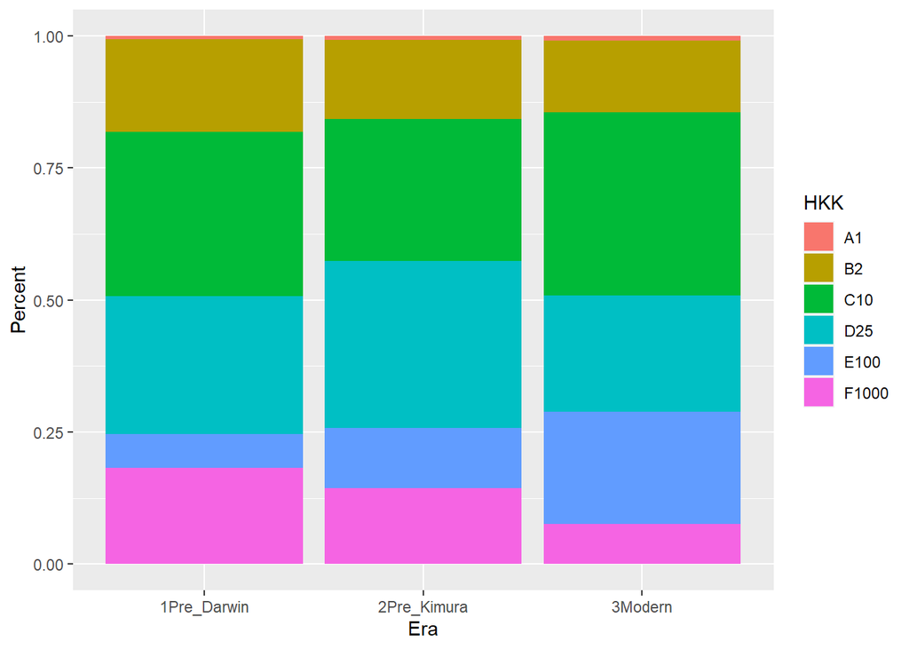

This is significant but the trends are messay and I haven’t thought them through. Clearest result is that when HKK=1000, the proportion diminishes through time, contrary to expectations.

# Accessibility of habitat when species described - Percentage of CS in inaccessible habitats higher in earlier spp?

```
##
##        Difficult Easy Normal
##   1750         4   10     34
##   1760         1    4     15
##   1770         2    5     15
##   1780         1    2     11
##   1790         2    6     18
##   1800         2    6     16
##   1810         3    3     16
##   1820         3    8     38
##   1830         4   15     36
##   1840         4   10     56
##   1850         2   10     32
##   1860         2   15     42
##   1870         8    8     29
##   1880         6    1     33
##   1890         2    6     19
##   1900         2    2     22
##   1910         6    2      8
##   1920         2    2     16
##   1930         1    5     13
##   1940         0    1      7
##   1950         2    2     12
##   1960         0    2     11
##   1970         3    4     10
##   1980        15    2      6
##   1990         3    2     15
##   2000         7   11     29
##   2010         4    7     31
```

```
##
##  Pearson's Chi-squared test
##
## data:  decadeAccess$decade and decadeAccess$Access
## X-squared = 122.28, df = 52, p-value = 1.366e-07
```

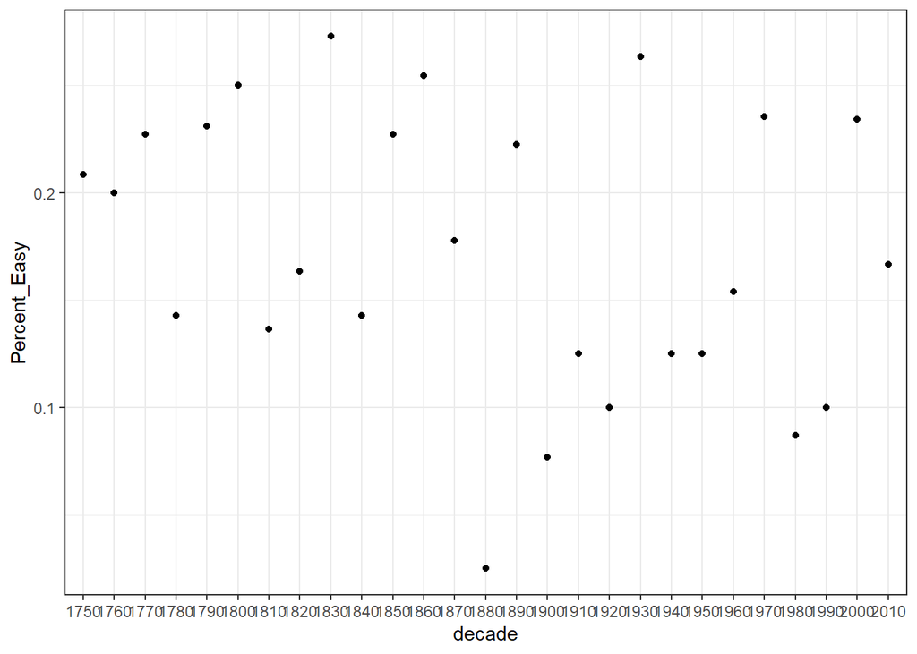

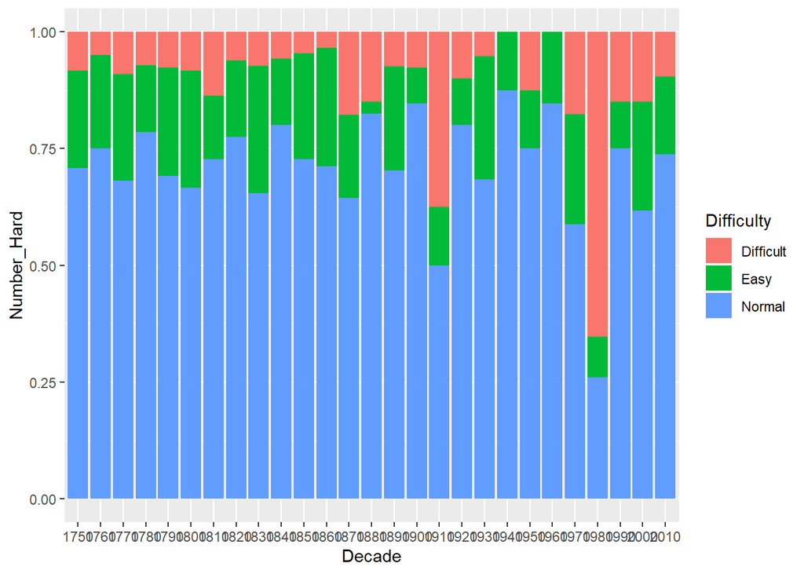

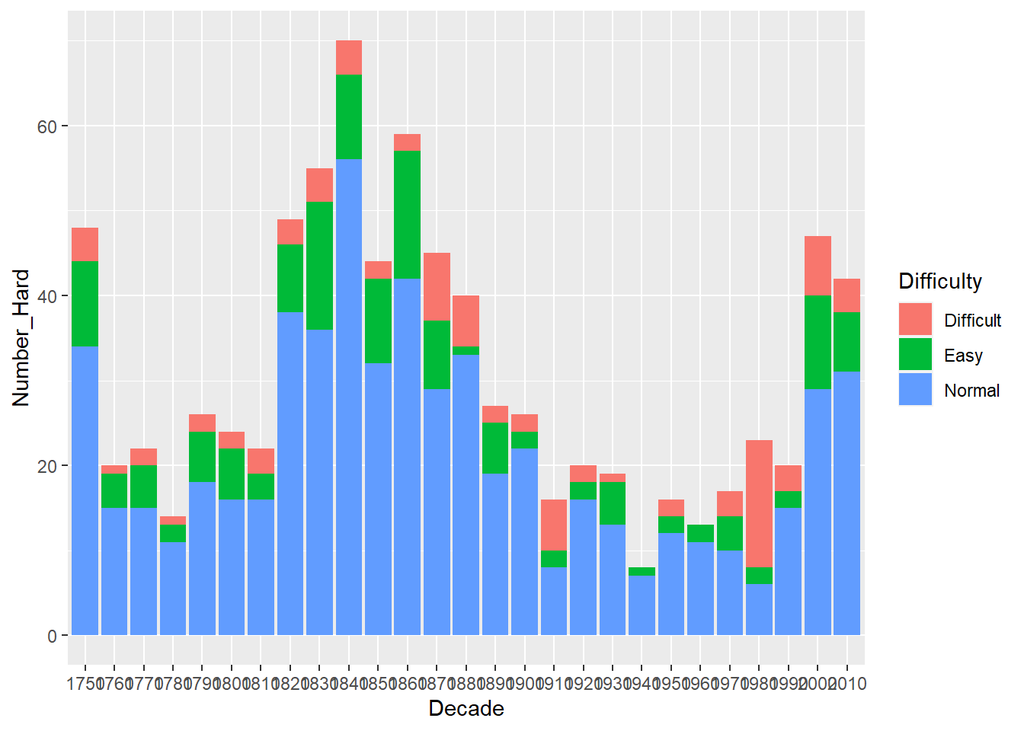

Again a statistically significant result but no clear trend like we expect; hypothesis not supported overall. BUT looking at percent difficult shows clearer patterns (increase through time).

## In sum, when we only look at species with CS (i.e. our database), the effect of taxonomic work goes away. This is interesting since that was the strongest effect in paper 1.

## Effect of recent divergence - dispersal

# Larval type – Planktotrophic/pelagic larvae leads to less CS/NS)?

Note1: for this I’m working with a separate surveylarv input file where I have corrected larval types to pt, lt, dd, and removed all others, including cases where there are multiple types checked. (Most of those cases are where the two CS have different larvae.) This left 574 CS with larval info.

Note2: the data fail the homoscedasticity test (Bartlett’s) so I’ve used a nonparametric Kruskal-Wallis test to see if CS/NS is different among groups.

```
##       DD       LT       PT
## 3.552632 3.372881 3.154605
```

```
##       DD       LT       PT
## 2.421727 3.079562 3.106330
```

```
##
##  Kruskal-Wallis rank sum test
##
## data:  as.numeric(larv_NbCS$Nb_CS) and larv_NbCS$Larv_type
## Kruskal-Wallis chi-squared = 7.9247, df = 2, p-value = 0.01902
```

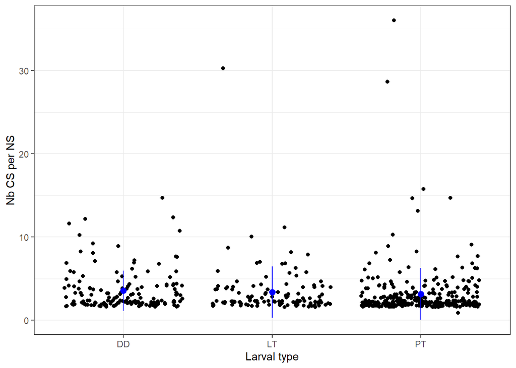

Result: larvae with direct development have the highest number of CS/NS, and this is significant, but the graph doesn’t make this obvious (lots of noise). Hypothesis supported.

# High HKK leads to more CS ss – testing this based on Nb_CS per HKK.

Note: data again failed homoscedasticity, using Kruskal Wallis test

```
##        1        5       10       25      100     1000
## 3.888889 3.285714 3.480159 2.977679 3.081395 3.446970
```

```
##        1        5       10       25      100     1000
## 2.891559 2.067359 3.072109 2.334080 1.660724 3.744338
```

```
##
##  Kruskal-Wallis rank sum test
##
## data:  HKK_NbCS$Nb_CS and HKK_NbCS$HKKv3
## Kruskal-Wallis chi-squared = 4.9941, df = 5, p-value = 0.4166
```

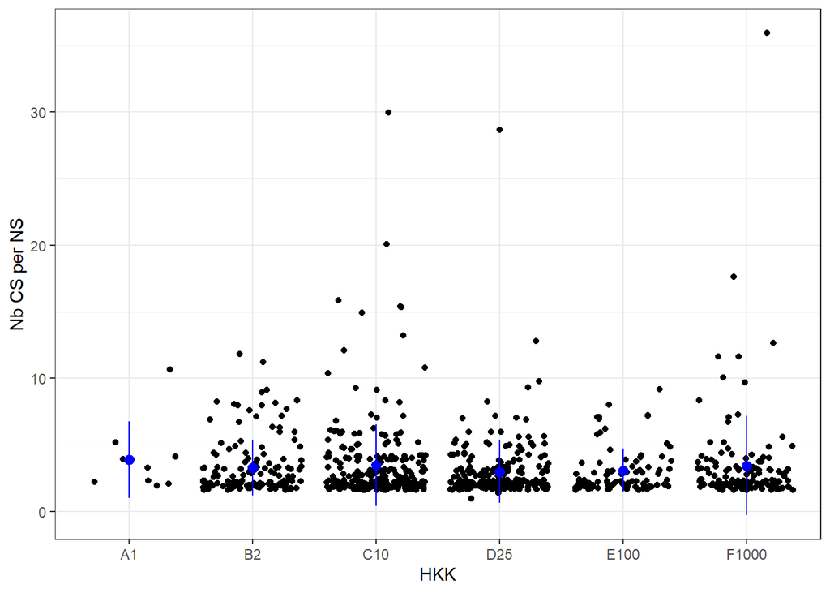

Result: No difference in the number of CS per NS across HKK classes; the average for all is around 3. Hypothesis not supported.

## In sum, support for the role of recent divergence as measured by a proxy of dispersal is equivocal and depends on the proxy used.

# More stable environments = more CSss or statistical differences

Note: stable = pelagic, deepsea, cave, coralreef; not stable = coastal, intertidal, estuarine, seagrass

```
##
##         FALSE TRUE
##   FALSE   103   49
##   TRUE    190  135
```

```
##
##  Pearson's Chi-squared test with Yates' continuity correction
##
## data:  stable_hab$CSss and stable_hab$Stable
## X-squared = 3.3992, df = 1, p-value = 0.06523
```

```
##                FALSE      TRUE
## CSss_total 0.6484642 0.7336957
## CSsl_total 0.3515358 0.2663043
```

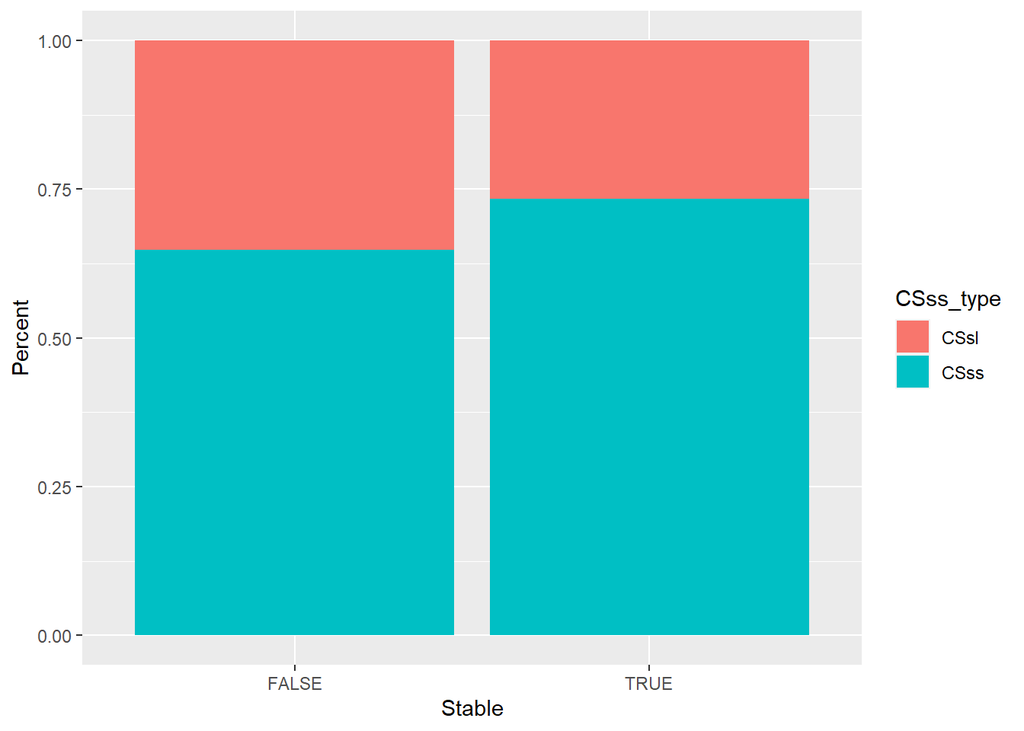

Result: marginal - but in predicted direction. More CSss found in stable environments. Hypothesis supported.

# Note also that stabilizing selection predicts more CSss than CSsl, which is what we find (see above).

## In sum, we generally have support for this idea.

## High Ne (neutral hypotheses)

# Reproductive investment - Low reproductive investment leads to more statistical divergence? (Repro. investment proxy for Ne)

Note1: Again this uses the surveylarv dataset with hand cleaning. Note2: Planktotrophic = LOW; Lecithotrophic, Brooding, DD = HIGH; If a spp could be both low and high, have marked it NA (is usually bc the CS have different larval types). Anything else got marked NA to be conservative. Note3: Only 294 cases are considered here, meaning that is where we have morphological data AND larval type data

```
##
##                      HIGH LOW
##   Diagnostic           47  49
##   No differentiation   36  47
##   Statistic            55  60
```

```
##
##  Pearson's Chi-squared test
##
## data:  surveylarv$Morpho_diff and surveylarv$Repro_invest
## X-squared = 0.61716, df = 2, p-value = 0.7345
```

Result: not significant.

# High HKK leads to more CS ss (HKK as proxy for Ne)

```
##
##                       1  5 10 25 100 1000
##   Diagnostic          4 33 46 45   8    7
##   No differentiation  1 20 36 38  21   10
##   Statistic           0 35 55 33  13   32
```

```
##              1         5        10        25       100      1000
## stat_total 0.0 0.3977273 0.4014599 0.2844828 0.3095238 0.6530612
## diag_total 0.8 0.3750000 0.3357664 0.3879310 0.1904762 0.1428571
## nod_total  0.2 0.2272727 0.2627737 0.3275862 0.5000000 0.2040816
```

```
##
##    1    5   10   25  100 1000
##    5   88  137  116   42   49
```

```
##
##  Pearson's Chi-squared test
##
## data:  surveymorpho$Morpho_diff and surveymorpho$HKKv3
## X-squared = 37.683, df = 10, p-value = 4.309e-05
```

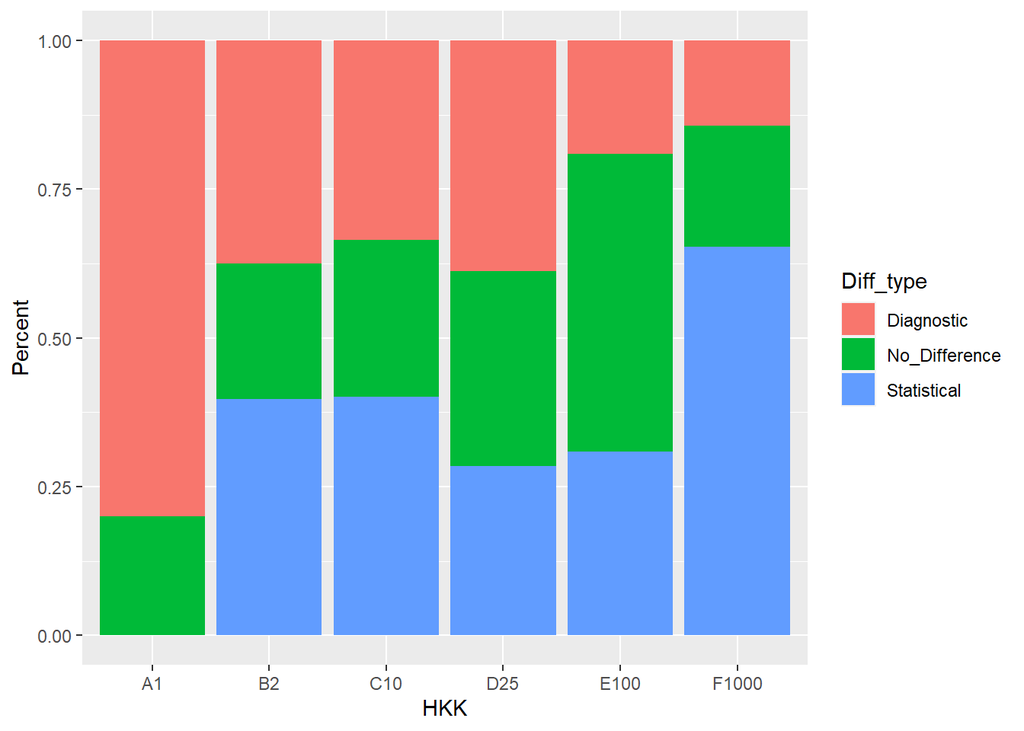

```
##
##        FALSE TRUE
##   1        4    1
##   5       33   55
##   10      46   91
##   25      45   71
##   100      8   34
##   1000     7   42
```

```
##
##  Pearson's Chi-squared test
##
## data:  surveymorpho$HKKv3 and surveymorpho$CSss
## X-squared = 19.109, df = 5, p-value = 0.001834
```

```
##              1     5        10       25       100      1000
## CSss_total 0.2 0.625 0.6642336 0.612069 0.8095238 0.8571429
## CSsl_total 0.8 0.375 0.3357664 0.387931 0.1904762 0.1428571
```

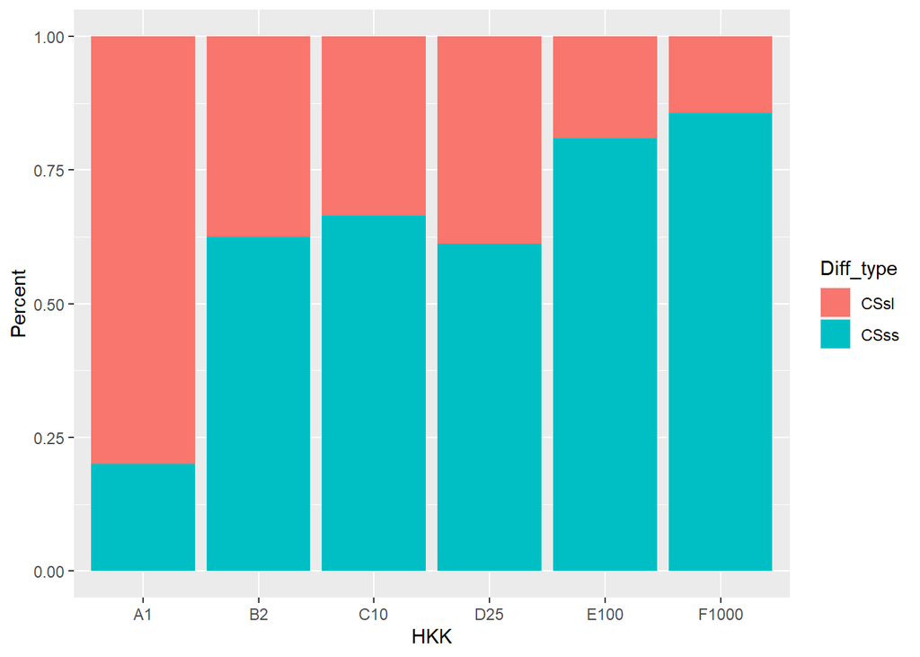

Results: More diagnostic differences (=CSsl) at lower HKK values, both when considering 3 morpho classes AND just ss vs sl

## In sum, we see support for the neutral hypothesis if we use HKK as a proxy for Ne but NOT if we use reproductive investment.

## Hypothesis: effect of recent divergence – More sympatric than allopatric CS/NS for a given Nsg?

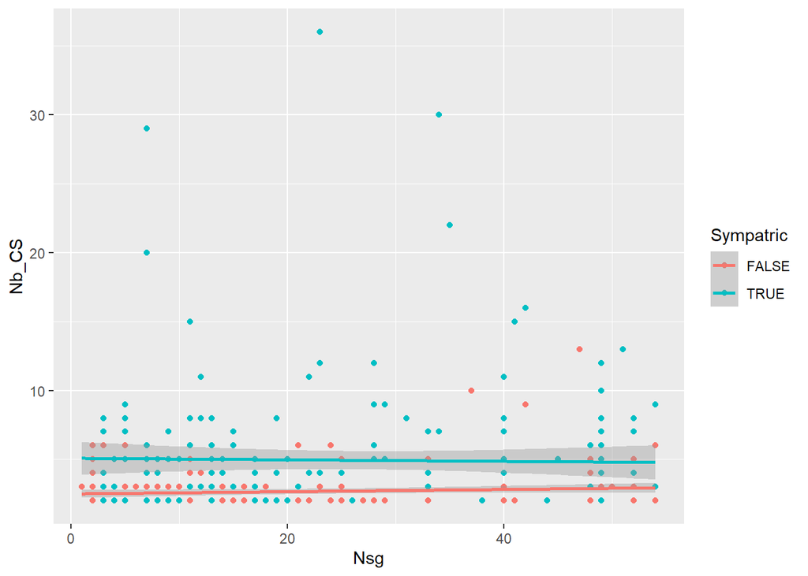

```
## ANOVA Table (type II tests)
##
##      Effect DFn DFd     F     p p<.05      ges
## 1     Nb_CS   1 411 0.041 0.840       9.91e-05
## 2 Sympatric   1 411 1.589 0.208       4.00e-03
```

These results aren’t statistically significant (ANCOVA) but the graph is in line with the hypothesis. Marginal support.

## Selection against hybrids – More diagnostic differences in sympatry than allopatry?

```
##
##         FALSE TRUE
##   FALSE    68   36
##   TRUE    100   93
```

```
##
##  Pearson's Chi-squared test with Yates' continuity correction
##
## data:  surveymorpho$CSss and surveymorpho$Sympatric
## X-squared = 4.5289, df = 1, p-value = 0.03333
```

```
##                FALSE      TRUE
## CSss_total 0.5952381 0.7209302
## CSsl_total 0.4047619 0.2790698
```

[figure not shown]

## Importance of biological traits

# More diagnostic traits with hard skeleton?

```
##
##                        N   Y
##   Diagnostic          33 112
##   No differentiation  47  88
##   Statistic           40 129
```

```
##
##  Pearson's Chi-squared test
##
## data:  surveymorpho$Morpho_diff and surveymorpho$hard_skeleton
## X-squared = 6.4826, df = 2, p-value = 0.03911
```

```
##                    N         Y
## stat_total 0.3333333 0.3920973
## diag_total 0.2750000 0.3404255
## nod_total  0.3916667 0.2674772
```

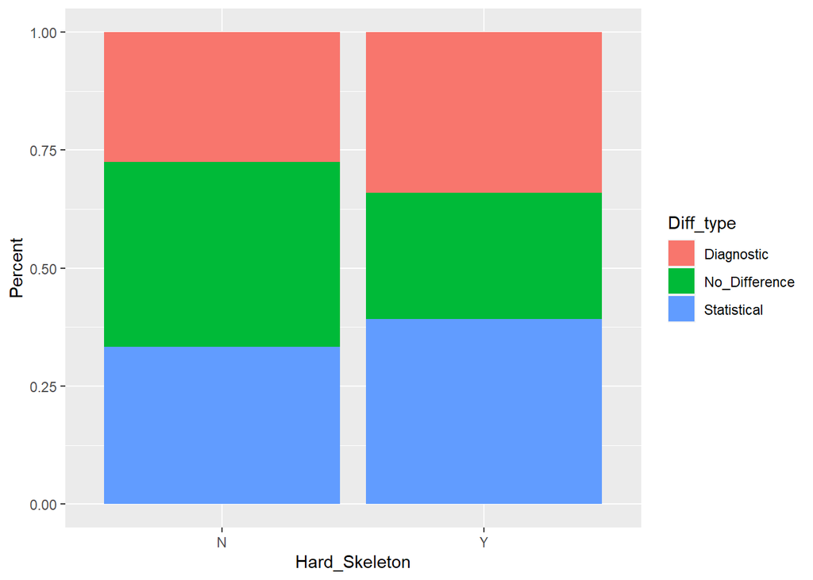

Note: We do not get the same result if I just consider ss vs sl - there is no longer significance. I think this is because hard skeleton should be important for both statistical and diagnostic differences. Result: hypothesis supported.

# More diagnostic traits with image vision?

```
##
##                       N  Y
##   Diagnostic         64 81
##   No differentiation 75 60
##   Statistic          82 87
```

```
##
##  Pearson's Chi-squared test
##
## data:  surveymorpho$Morpho_diff and surveymorpho$image
## X-squared = 3.6995, df = 2, p-value = 0.1573
```

Result: hypothesis not supported

# More diagnostic traits with internal fertilization?

```
##
##                       B  E  I
##   Diagnostic         50 53 42
##   No differentiation 47 65 23
##   Statistic          37 86 46
```

```
##
##  Pearson's Chi-squared test
##
## data:  surveymorpho$Morpho_diff and surveymorpho$ferti
## X-squared = 14.293, df = 4, p-value = 0.006416
```

```
##                    B         E         I
## stat_total 0.2761194 0.4215686 0.4144144
## diag_total 0.3731343 0.2598039 0.3783784
## nod_total  0.3507463 0.3186275 0.2072072
```

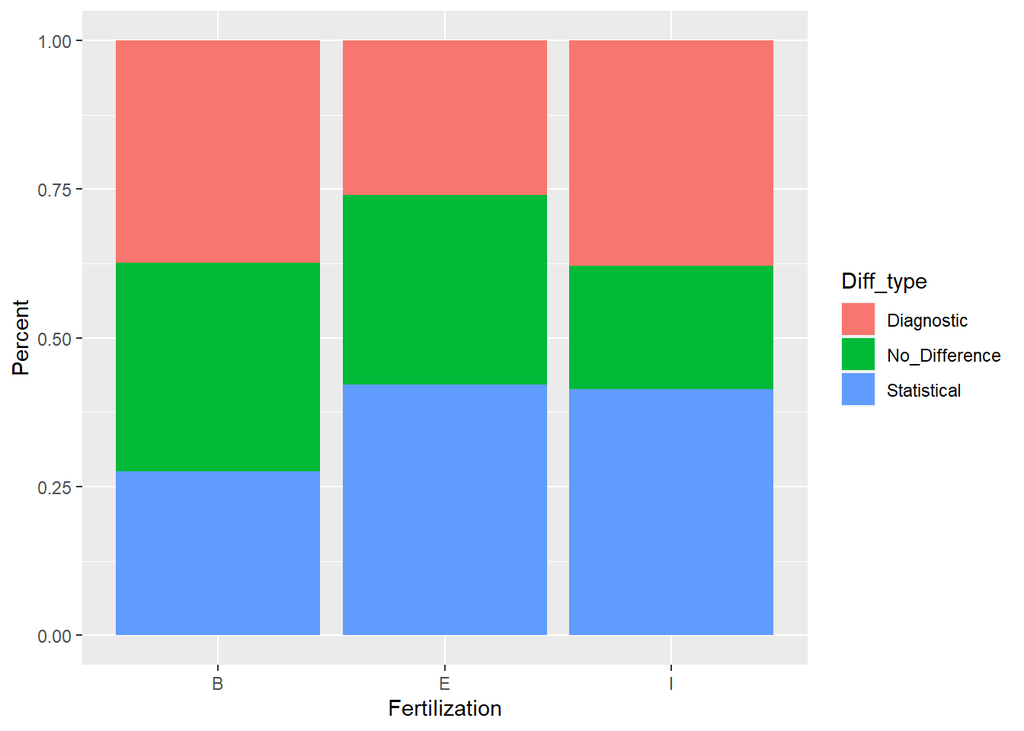

Result: hypothesis supported. Species with internal fert are more likely to have diag diffs, ie CSsl. This is also true if I remove the “both” category. Hypothesis accepted.

# More diagnostic traits with external genitalia?

```
##
##                        B   N   Y
##   Diagnostic          30  75  40
##   No differentiation  30  85  20
##   Statistic           16 111  42
```

```
##
##  Pearson's Chi-squared test
##
## data:  surveymorpho$Morpho_diff and surveymorpho$genitals
## X-squared = 17.304, df = 4, p-value = 0.001687
```

```
##                    B         N         Y
## stat_total 0.2105263 0.4095941 0.4117647
## diag_total 0.3947368 0.2767528 0.3921569
## nod_total  0.3947368 0.3136531 0.1960784
```

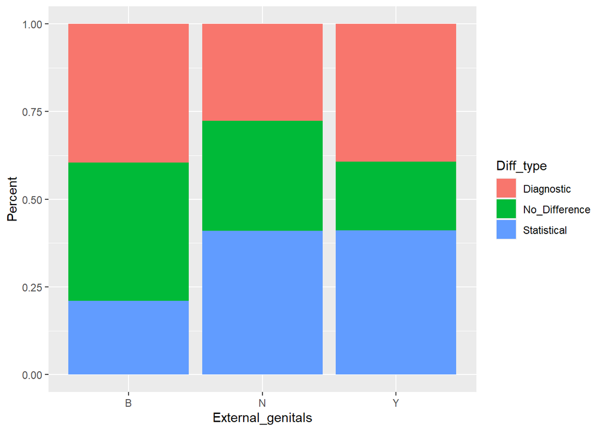

Result: more diagnostic traits with external, hypothesis accepted. This is also true if only considering CSss and CSsl, AND when gastropods are removed (the only class with “both”).

## In sum, except “image vision” we still see an importance of taxonomic characters in determining the TYPE of CS that is found (ss vs sl).

## So, overall conclusions: When looking at the full dataset, there is support for several (but not all) sets of hypotheses. Interestingly, the effect of taxonomic work/effort seems to go away, while the effect of taxonomic class remains. Some support for both selection-based and neutral ideas.